# Exampl_t_ANOVA.Rmd

F. A. Barrios Instituto de Neurobiología UNAM

2020-10-20

# 1 Examples Chap03 (Vittinghoff et al. book)

The examples for chapter 3 (Vittinghoff’s book http://www.biostat.ucsf.edu/vgsm) using data from the heart and estrogen/progestin study (HERS), a clinical trial of hormone therapy (HT) for prevention of recurrent heart attacks and death among 2,763 post-menopausal women with existing coronary heart disease (CHD)

## 1.1 Introduction

t-Test example presented in Table 3.1 of the t-Test of difference in average glucose by exercise for the women that are not diabetic. These examples are to revisit some t-test R estimations and t-test function in R. And to remember that a Boxplot gives a good amount of information about a numerical variable: Centering described by the median Dispersion, measured by the hight of the box (interquartil distance). Observation range The presence of extreme values (outliers) And some information of the distribution “form” (skewness)

```r
setwd("~/Dropbox/Fdo/ClaseStats/RegressionClass/RegressionR_code")
# To set the working directory at the user dir
library(tidyverse)
library(multcomp)
library(car)
library(emmeans)

hers <- read_csv("DataRegressBook/Chap3/hersdata.csv")
```

```r
# Loading the HERS database in hers variable
summary(hers)
```

```
      HT                 age           raceth            nonwhite
 Length:2763        Min.   :44.00   Length:2763        Length:2763
 Class :character   1st Qu.:62.00   Class :character   Class :character
 Mode  :character   Median :67.00   Mode  :character   Mode  :character
                    Mean   :66.65
                    3rd Qu.:72.00
                    Max.   :79.00

   smoking            drinkany           exercise           physact
 Length:2763        Length:2763        Length:2763        Length:2763
 Class :character   Class :character   Class :character   Class :character
 Mode  :character   Mode  :character   Mode  :character   Mode  :character




   globrat            poorfair            medcond         htnmeds
 Length:2763        Length:2763        Min.   :0.0000   Length:2763
 Class :character   Class :character   1st Qu.:0.0000   Class :character
 Mode  :character   Mode  :character   Median :0.0000   Mode  :character
                                       Mean   :0.3721
                                       3rd Qu.:1.0000
                                       Max.   :1.0000

   statins            diabetes           dmpills            insulin
 Length:2763        Length:2763        Length:2763        Length:2763
 Class :character   Class :character   Class :character   Class :character
 Mode  :character   Mode  :character   Mode  :character   Mode  :character




     weight            BMI            waist             WHR
 Min.   : 37.50   Min.   :15.21   Min.   : 56.90   Min.   :0.624
 1st Qu.: 62.20   1st Qu.:24.64   1st Qu.: 82.00   1st Qu.:0.811
 Median : 71.00   Median :27.75   Median : 90.50   Median :0.867
 Mean   : 72.73   Mean   :28.58   Mean   : 91.74   Mean   :0.870
 3rd Qu.: 81.40   3rd Qu.:31.73   3rd Qu.:100.30   3rd Qu.:0.923
 Max.   :132.00   Max.   :54.13   Max.   :170.00   Max.   :1.218
 NA's   :2        NA's   :5       NA's   :2        NA's   :3
```

[output cut: 24 more lines]

```
      HDL1             TG1              SBP             DBP
 Min.   : 14.00   Min.   :  31.0   Min.   : 83.0   Min.   : 45.00
 1st Qu.: 42.00   1st Qu.: 119.0   1st Qu.:122.0   1st Qu.: 67.00
 Median : 50.00   Median : 157.0   Median :134.0   Median : 72.00
 Mean   : 51.78   Mean   : 175.8   Mean   :135.1   Mean   : 73.15
 3rd Qu.: 59.00   3rd Qu.: 214.0   3rd Qu.:147.0   3rd Qu.: 80.00
 Max.   :124.00   Max.   :1016.0   Max.   :224.0   Max.   :102.00
 NA's   :155      NA's   :150                      NA's   :1
     age10
 Min.   :4.400
 1st Qu.:6.200
 Median :6.700
 Mean   :6.665
 3rd Qu.:7.200
 Max.   :7.900
```

```
    Two Sample t-test

data:  glucose[hers$diabetes == "no"] by exercise[hers$diabetes == "no"]
t = 3.8685, df = 2030, p-value = 0.000113
alternative hypothesis: true difference in means is not equal to 0
95 percent confidence interval:
 0.8346242 2.5509539
sample estimates:
 mean in group no mean in group yes
         97.36104          95.66825
```

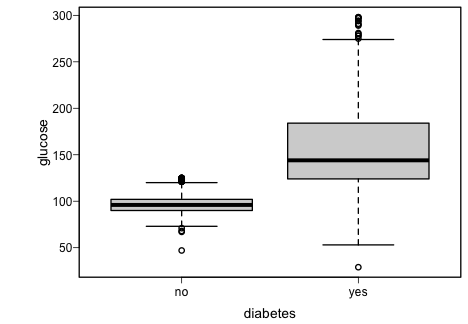

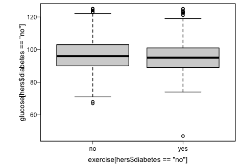

```r
boxplot(glucose ~ diabetes, data=hers)
# Some graphical description of the glucose state
boxplot(glucose[hers$diabetes == "no"] ~ exercise[hers$diabetes == "no"], alternative="two.sided", data=hers)
t.test(glucose[hers$diabetes == "no"] ~ exercise[hers$diabetes == "no"], data=hers, alternative="two.sided", mu=0, paired=FALSE, var.equal=TRUE)
```

## t-test examles Examples of t-test from the exercises of the Daniel’s book, Chap 7, section 3 number 3. Data can be downloaded from the WEB page of the Daniel’s book

```r
setwd("~/Dropbox/Fdo/ClaseStats/RegressionClass/RegressionR_code")
# Daniel's chap 7 t-test examples
# EXR_C07_S03_03
Ex733 = read.csv(file="DataOther/EXR_C07_S03_03.csv", header=TRUE)
names(Ex733)
```

```
[1] "Length" "Group"
```

```r
summary(Ex733)
```

```
     Length           Group
 Min.   : 88.25   Min.   :1.000
 1st Qu.: 94.55   1st Qu.:1.000
 Median :101.00   Median :1.000
 Mean   :102.13   Mean   :1.413
 3rd Qu.:109.47   3rd Qu.:2.000
 Max.   :128.95   Max.   :2.000
```

```r
# In parts
NoOSAS = Ex733$Length[Ex733$Group == 1]
OSAS = Ex733$Length[Ex733$Group == 2]
#
boxplot(NoOSAS,OSAS)
var.test(OSAS, NoOSAS)
```

```
    F test to compare two variances

data:  OSAS and NoOSAS
F = 1.5494, num df = 25, denom df = 36, p-value = 0.2253
alternative hypothesis: true ratio of variances is not equal to 1
95 percent confidence interval:
 0.7606111 3.3152356
sample estimates:
ratio of variances
          1.549382
```

```r
t.test(NoOSAS, OSAS, alternative="less", conf.level=0.99)
```

```
    Welch Two Sample t-test

data:  NoOSAS and OSAS
t = -9.2441, df = 46.217, p-value = 2.229e-12
alternative hypothesis: true difference in means is less than 0
99 percent confidence interval:
      -Inf -11.24172
sample estimates:
mean of x mean of y
 95.85405 111.05962
```

```
    Welch Two Sample t-test

data:  Length by Group
t = -9.2441, df = 46.217, p-value = 2.229e-12
alternative hypothesis: true difference in means is less than 0
99 percent confidence interval:
      -Inf -11.24172
sample estimates:
mean in group 1 mean in group 2
       95.85405       111.05962
```

[figure not shown]

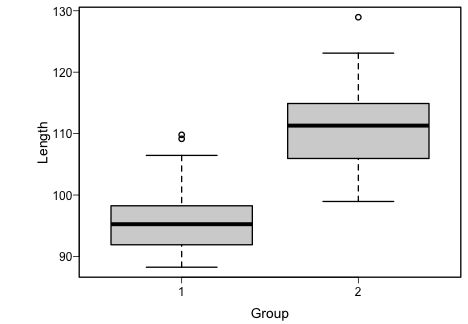

```r
#
# Shorter and direct
boxplot(Length ~ Group, data=Ex733)
t.test(Length ~ Group, data=Ex733, alternative="less", conf.level=0.99)
```

How it looks for several variables an ANOVA example using the HERS data refering to the diabetic participants.

```r
#  Example of the HERS data for diabetic participants
hers_yesdi <- filter(hers, diabetes == "yes")
hers_yesdi <- mutate(hers_yesdi, physact = factor(physact, levels=c("much less active","somewhat less active","about as active","somewhat more active","much more active")))

#  Example of ANOVA with HERS data for diabetic participants
#
ggplot(data = hers_yesdi, mapping = aes(x = physact, y = glucose)) + geom_boxplot(na.rm = TRUE)
glucose_yesdi_act <- lm(glucose ~ physact, data = hers_yesdi)
Anova(glucose_yesdi_act, type="II")
```

```
Anova Table (Type II tests)

Response: glucose
           Sum Sq  Df F value Pr(>F)
physact     17992   4   1.925 0.1044
Residuals 1696313 726
```

```r
#
S(glucose_yesdi_act)
```

```
Call: lm(formula = glucose ~ physact, data = hers_yesdi)

Coefficients:
                            Estimate Std. Error t value Pr(>|t|)
(Intercept)                  155.789      5.095  30.575   <2e-16 ***
physactsomewhat less active   -4.590      6.235  -0.736    0.462
physactabout as active         5.191      5.958   0.871    0.384
physactsomewhat more active   -1.398      6.362  -0.220    0.826
physactmuch more active      -11.789      8.320  -1.417    0.157
---
Signif. codes:  0 '***' 0.001 '**' 0.01 '*' 0.05 '.' 0.1 ' ' 1

Residual standard deviation: 48.34 on 726 degrees of freedom
Multiple R-squared: 0.0105
F-statistic: 1.925 on 4 and 726 DF,  p-value: 0.1044
    AIC     BIC
7751.41 7778.98
```

```r
glucose_emmeans <- emmeans(glucose_yesdi_act, "physact")
contrast(glucose_emmeans, adjust="sidak")
```

```
 contrast                    estimate   SE  df t.ratio p.value
 much less active effect         2.52 4.45 726  0.565  0.9856
 somewhat less active effect    -2.07 3.46 726 -0.599  0.9815
 about as active effect          7.71 3.16 726  2.441  0.0722
 somewhat more active effect     1.12 3.60 726  0.311  0.9991
 much more active effect        -9.27 5.50 726 -1.687  0.3830

P value adjustment: sidak method for 5 tests
```

[figure not shown]

# 2 Example from R-bloggers

First we build four random variables with two different distributions.

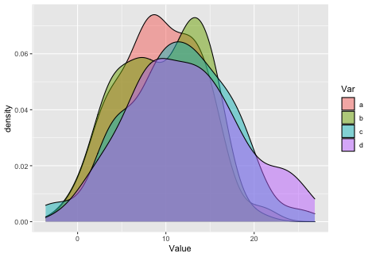

```r
# Create the four groups
set.seed(10)
df1 <- data.frame(Var="a", Value=rnorm(100,10,5))
df2 <- data.frame(Var="b", Value=rnorm(100,10,5))
df3 <- data.frame(Var="c", Value=rnorm(100,11,6))
df4 <- data.frame(Var="d", Value=rnorm(100,11,6))

# merge them in one data frame
df<-rbind(df1,df2,df3,df4)

# convert Var to a factor
df$Var<-as.factor(df$Var)
df%>%ggplot(aes(x=Value, fill=Var))+geom_density(alpha=0.5)
```

## The ANOVA (taken from R-bloggers) ANOVA (ANalysis Of VAriance) is a statistical test used to compare two or more groups to see if they are significantly different. The ANOVA model and some examples. The null hypothesis in ANOVA is that there is no difference between means and the alternative is that the means are not all equal. This means that when we are dealing with many groups, we cannot compare them pairwise. We can simply answer if the means between groups can be considered as equal or not.

```r
# ANOVA
model1<-lm(Value~Var, data=df)
anova(model1)
```

```
Analysis of Variance Table

Response: Value
           Df  Sum Sq Mean Sq F value    Pr(>F)
Var         3   565.7 188.565   6.351 0.0003257 ***
Residuals 396 11757.5  29.691
---
Signif. codes:  0 '***' 0.001 '**' 0.01 '*' 0.05 '.' 0.1 ' ' 1
```

## 2.1 Tukey multiple comparisons

What about if we want to compare all the groups pairwise? In this case, we can apply the Tukey’s HSD which is a single-step multiple comparison procedure and statistical test, Tukey’s Honest Significant Difference (Tukey’s HSD). It can be used to find means that are significantly different from each other.

```r
summary(glht(model1, mcp(Var="Tukey")))
```

```
     Simultaneous Tests for General Linear Hypotheses

Multiple Comparisons of Means: Tukey Contrasts


Fit: lm(formula = Value ~ Var, data = df)

Linear Hypotheses:
           Estimate Std. Error t value Pr(>|t|)
b - a == 0   0.2079     0.7706   0.270  0.99312
c - a == 0   1.8553     0.7706   2.408  0.07727 .
d - a == 0   2.8758     0.7706   3.732  0.00129 **
c - b == 0   1.6473     0.7706   2.138  0.14298
d - b == 0   2.6678     0.7706   3.462  0.00329 **
d - c == 0   1.0205     0.7706   1.324  0.54795
---
Signif. codes:  0 '***' 0.001 '**' 0.01 '*' 0.05 '.' 0.1 ' ' 1
(Adjusted p values reported -- single-step method)
```